# Exponential distributions and the Central Limit Theorem

@tribetect

August 18, 2015

# Overview

We investigate the exponential distribution and compare it with the Central Limit Theorem (CLT) by simulating random exponential values, and contrasting the characteristics of such values against a normal distribution.

# Simulations

A base set of random exponential values is generated by repeatedly sampling, 40 values at a time, from the exponential distribution.

1. The exponential distribution was simulated in R with rexp(samplesize, lambda) where lambda is the rate parameter, given as 0.2 for this assignment.
2. The mean of exponential distribution is 1/lambda and the standard deviation is also 1/lambda, or 1/.2 = 5 for this assignment.

```r
my_seed = 512 #for random number generators based simulations
set.seed(my_seed)

# Setup the supplied quantities as variables
lambda <- 0.2
samplesize <- 40 #size of random exponential samples
nosim = 1000 #number of simulations
sample_means = NULL #variable to store means of samples
sample_var = NULL #variances of samples
```

# Comparing Sample Mean and Theoretical Mean

We plot the distribution of a 1000 simulated means of sampletaken from an exponential distribution. Size of each sample was 40.

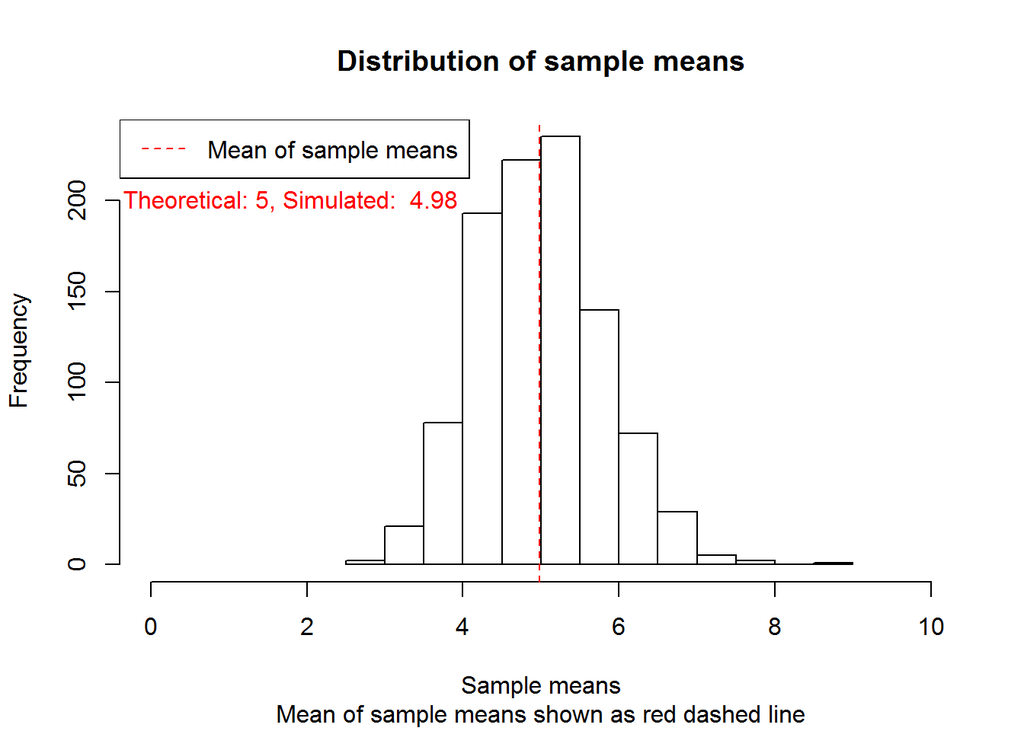

```r
for (i in 1 : nosim) sample_means = c(sample_means, mean(rexp(samplesize, lambda)))
hist(sample_means, main = "Distribution of sample means", xlab = "Sample means",xlim = c(0,10), sub = "Mean of sample means shown as red dashed line")
theo_mean <- mean(sample_means)
abline(v = theo_mean, col = "red", lty = 2)
text(x = 1.8, y = 200, labels = paste("Theoretical: 5, Simulated: ", round(theo_mean,2)), col = "red")
legend("topleft", legend = "Mean of sample means", lty = 2, col = "red")
```

# Comparing Distributions

## The distribution of means is approximately symmetrical around the mean, as shown from the figure above and the close values of mean and median:

```r
mean(sample_means)
```

```
## [1] 4.97779
```

```r
median(sample_means)
```

```
## [1] 4.94445
```

# Sample Variance versus Theoretical Variance

## Theoretical variance

Variance is (standard deviation)^2 For the given distribution, standard deviation = 1/lambda, i.e. 1/0.2 = 5

```r
theo_variance = (1/lambda)^2
theo_variance
```

```
## [1] 25
```

## Variance from simulation

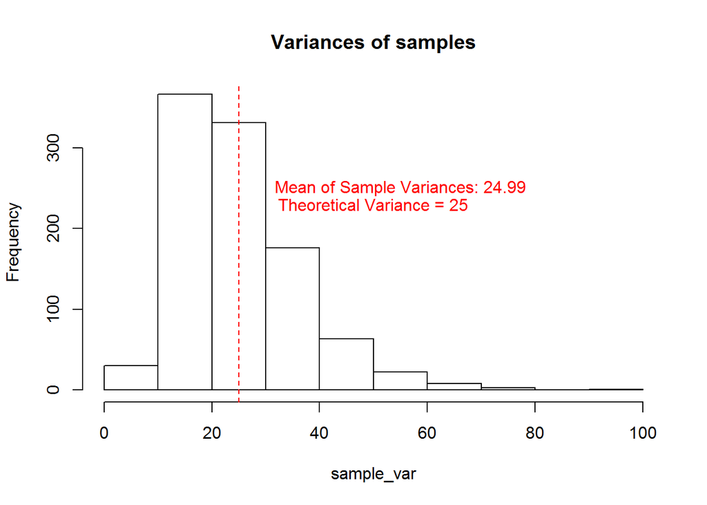

```r
set.seed(my_seed)
for (i in 1 : nosim) sample_var = c(sample_var, var(rexp(samplesize, lambda)))
hist(sample_var, main = "Variances of samples")
abline(v = theo_variance, col = "red", lty = 2)
text(theo_variance + 25, y = 230, labels = paste("Theoretical Variance = 25"), col = "red")
text(theo_variance + 30, y = 250, labels = paste("Mean of Sample Variances:", round(mean(sample_var),2)), col = "red")
```

### The mean of sample variances is very close to the theoretical variance of 25

## This concludes part 1 of the project